# Winter

Sarah Hvid Andersen

8/9/2020

creating winters data

```r
pitch = c(233,204,242,130,112,142)
sex = c(rep("female",3),rep("male",3))
my.df = data.frame(sex,pitch)
```

```r
xmdl = lm(pitch ~ sex, my.df)
summary(xmdl)
```

```
##
## Call:
## lm(formula = pitch ~ sex, data = my.df)
##
## Residuals:
##       1       2       3       4       5       6
##   6.667 -22.333  15.667   2.000 -16.000  14.000
##
## Coefficients:
##             Estimate Std. Error t value Pr(>|t|)
## (Intercept)   226.33      10.18  22.224 2.43e-05 ***
## sexmale       -98.33      14.40  -6.827  0.00241 **
## ---
## Signif. codes:  0 '***' 0.001 '**' 0.01 '*' 0.05 '.' 0.1 ' ' 1
##
## Residual standard error: 17.64 on 4 degrees of freedom
## Multiple R-squared:  0.921,  Adjusted R-squared:  0.9012
## F-statistic: 46.61 on 1 and 4 DF,  p-value: 0.002407
```

```r
mean(my.df[my.df$sex=="female",]$pitch)
```

```
## [1] 226.3333
```

multiple r squared: variance accounted for, or explained by our predictor ‘sex’. it ranges form 0-1. ours is high at 0.921, and thus sex explains a lot of the variance in our data.

adjusted r squared: here it is taken into account how many fixed effects we used to explain our data.

the coefficients table looks at each fixed effect individually. the p-value here is how significant each coeff is. intercept is always significant, as the model asks if the value is non-zero (null-model?) - the intercept estimate is the mean female pitch value. female because it is first alphabetically (or, relevel()) - sexmale estimate is the difference in the male mean from the female mean.

reporting styles: “We constructed a linear model of pitch as a function of sex. This model  
was significant (F(1,4)=46.61, p<0.01). (…)”

```r
age = c(14,23,35,48,52,67)
pitch = c(252,244,240,233,212,204)
my.df = data.frame(age,pitch)
xmdl = lm(pitch ~ age, my.df)
summary(xmdl)
```

```
##
## Call:
## lm(formula = pitch ~ age, data = my.df)
##
## Residuals:
##      1      2      3      4      5      6
## -2.338 -2.149  4.769  9.597 -7.763 -2.115
##
## Coefficients:
##             Estimate Std. Error t value Pr(>|t|)
## (Intercept) 267.0765     6.8522   38.98 2.59e-06 ***
## age          -0.9099     0.1569   -5.80  0.00439 **
## ---
## Signif. codes:  0 '***' 0.001 '**' 0.01 '*' 0.05 '.' 0.1 ' ' 1
##
## Residual standard error: 6.886 on 4 degrees of freedom
## Multiple R-squared:  0.8937, Adjusted R-squared:  0.8672
## F-statistic: 33.64 on 1 and 4 DF,  p-value: 0.004395
```

when using a continous variable as fixed effect. intercept: now represents the estimated pitch for age 0. age: for every increase of age by 1 (unit of measurement) you decrease voice pitch by 0.9099 Hertz.

meaningful intercepts:

```r
#taking the age variable and subtracting the mean from the data, the data is now mean-centered.
my.df$age.c = my.df$age - mean(my.df$age)
xmdl = lm(pitch ~ age.c, my.df)
summary(xmdl)
```

```
##
## Call:
## lm(formula = pitch ~ age.c, data = my.df)
##
## Residuals:
##      1      2      3      4      5      6
## -2.338 -2.149  4.769  9.597 -7.763 -2.115
##
## Coefficients:
##             Estimate Std. Error t value Pr(>|t|)
## (Intercept) 230.8333     2.8113   82.11 1.32e-07 ***
## age.c        -0.9099     0.1569   -5.80  0.00439 **
## ---
## Signif. codes:  0 '***' 0.001 '**' 0.01 '*' 0.05 '.' 0.1 ' ' 1
##
## Residual standard error: 6.886 on 4 degrees of freedom
## Multiple R-squared:  0.8937, Adjusted R-squared:  0.8672
## F-statistic: 33.64 on 1 and 4 DF,  p-value: 0.004395
```

now the intercept is the predicted pitch at the mean age. this does not influence the model at all, but makes the intercept meaningful and interpretable.

assumption of the linear model: 1. linearity - do a residual plot. if it isn’t relatively linear (non-linear or curvy pattern), the assumption is violated. - either transform your data, or realize that a different model should be applied.

2. absence of collinearity
- when two fixed effects are correlated with each other, they are collinear. we don’t want that. if multiple fixed effects are very similar it becomes vary hard to see which ones are playing a bigger role. they steal each others explanatory power.
- either drop some ‘fixed effects’ or conduct a principal component analysis to gather the collinear data into a new fixed effect.
3. homoskedasticity - or absence of heteroskadisticity
- the variability of your data should be approximately equal across the range of your predicted values. it is a problem of unequal variance (hetero).
- do a residual plot. the residual have to have a roughly similar deviation from the predicted values(center line). a good plot looks blob-like.
- if not, transform data. log is good.
4. normality of residuals
- least important one, some don’t even bother (winter).
- qq plot.
- transform if you must.
5. absence of influential data points.
- influential data points can drastically change the model. not directly considered an assumption, but important for our results none the less.
- check with dfbeta(). if data point 1 is excluded, the slope has to be adjusted by the right side value (if slope is negative dfbeta value is substracted, if positive it is added). eyeball values, if any are half the size of the absolute slope value, the data point is alarming.
- if there are influential data points, run a model with and without the points and report both results.
6. independence
- most important assumption. more than one data point can’t come from the same subject. the model becomes completely meaningless then.
- with repeated measures design, do mixed models.

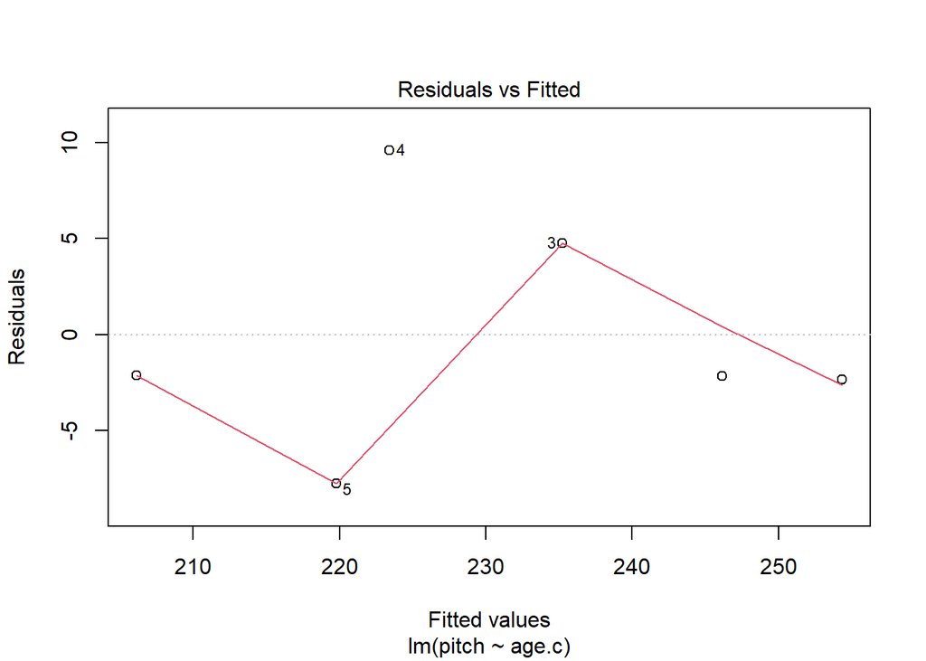

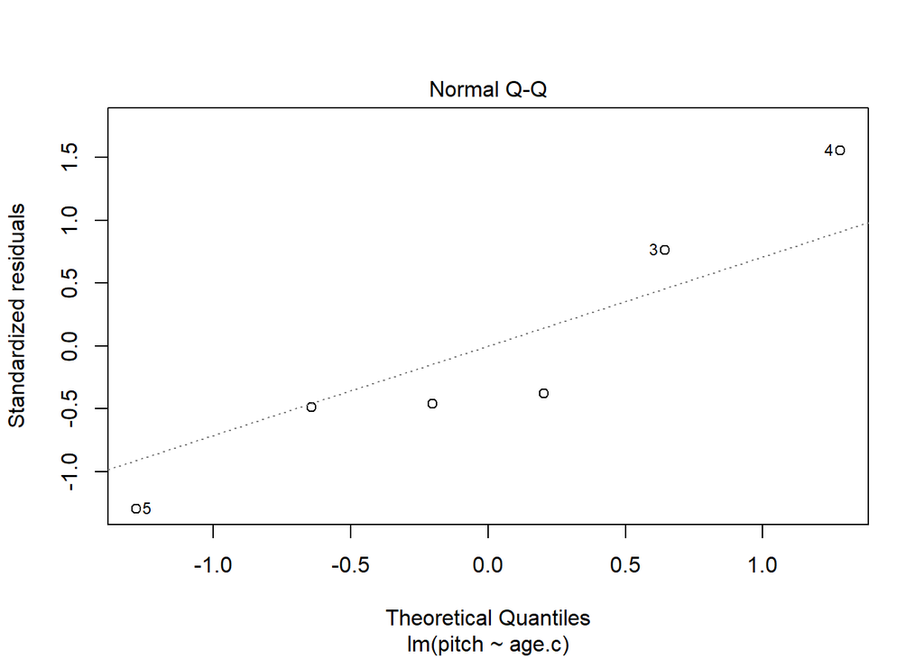

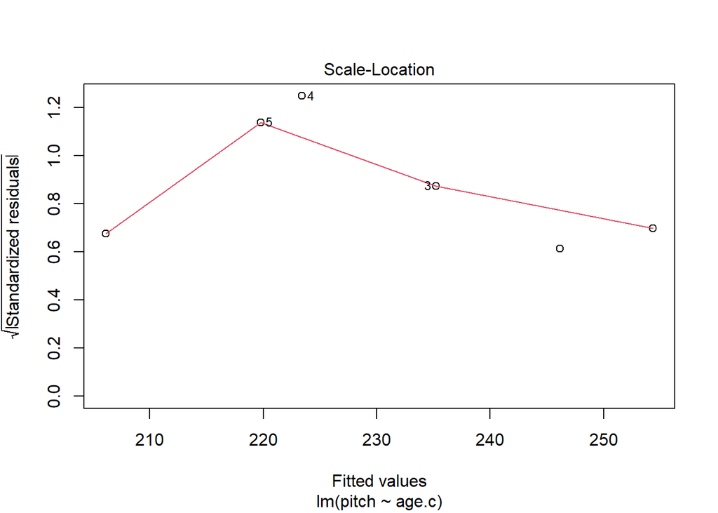

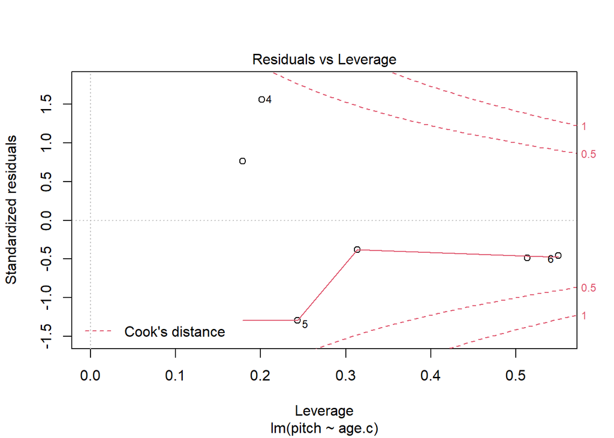

```r
plot(xmdl)
```

```r
dfbeta(xmdl)
```

```
##   (Intercept)       age.c
## 1  -0.8002664  0.06437573
## 2  -0.5220150  0.02736278
## 3   0.9678744 -0.01456709
## 4   2.0026352  0.05092767
## 5  -1.7103247 -0.06479736
## 6  -0.7828787 -0.06622744
```

Mixed effects models these allow us to use all of our data, without violating the assumption of independence.

```r
library(lme4)
```

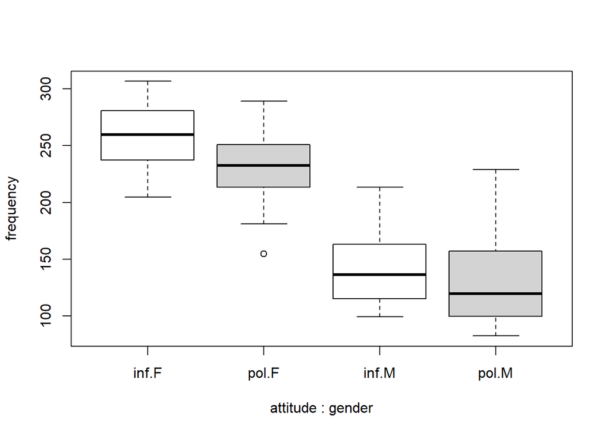

```r
politeness= read.csv("politeness_data.csv", header = T)

#plot to visualize data
boxplot(frequency ~ attitude*gender,
col=c("white","lightgray"),politeness)
```

```r
#create model
politeness.model = lmer(frequency ~ attitude +
(1|subject) + (1|scenario), data=politeness)
summary(politeness.model)
```

```
## Linear mixed model fit by REML ['lmerMod']
## Formula: frequency ~ attitude + (1 | subject) + (1 | scenario)
##    Data: politeness
##
## REML criterion at convergence: 793.5
##
## Scaled residuals:
##     Min      1Q  Median      3Q     Max
## -2.2006 -0.5817 -0.0639  0.5625  3.4385
##
## Random effects:
##  Groups   Name        Variance Std.Dev.
##  scenario (Intercept)  219     14.80
##  subject  (Intercept) 4015     63.36
##  Residual              646     25.42
## Number of obs: 83, groups:  scenario, 7; subject, 6
##
## Fixed effects:
##             Estimate Std. Error t value
## (Intercept)  202.588     26.754   7.572
## attitudepol  -19.695      5.585  -3.527
##
## Correlation of Fixed Effects:
##             (Intr)
## attitudepol -0.103
```

here, there are multiple hz registrations from each subject, and it therefore gets a random intercept. same goes for scenario, since each scenario has an informal and polite setting answered to them.

random effects sumarizes how much variance in our model is explained by scenario and subject. residual is the error there is still left in the model. fixed effects shows that to go from an informal attitude(intercept) to a polite attitude, hertz decreases by 20. here it si the average of all our data, regardless of sex, because it wasn’t included in the model. thus the intercept is again quite meaningless.

adding sex:

```r
politeness.model = lmer(frequency ~ attitude + gender +
(1|subject) + (1|scenario), data=politeness)
summary(politeness.model)
```

```
## Linear mixed model fit by REML ['lmerMod']
## Formula: frequency ~ attitude + gender + (1 | subject) + (1 | scenario)
##    Data: politeness
##
## REML criterion at convergence: 775.5
##
## Scaled residuals:
##     Min      1Q  Median      3Q     Max
## -2.2591 -0.6236 -0.0772  0.5388  3.4795
##
## Random effects:
##  Groups   Name        Variance Std.Dev.
##  scenario (Intercept) 219.5    14.81
##  subject  (Intercept) 615.6    24.81
##  Residual             645.9    25.41
## Number of obs: 83, groups:  scenario, 7; subject, 6
##
## Fixed effects:
##             Estimate Std. Error t value
## (Intercept)  256.846     16.116  15.938
## attitudepol  -19.721      5.584  -3.532
## genderM     -108.516     21.013  -5.164
##
## Correlation of Fixed Effects:
##             (Intr) atttdp
## attitudepol -0.173
## genderM     -0.652  0.004
```

the intercept now represents females for the informal condition. there is a clear drop in hz to the males. insight into different models with loglikelihood:

```r
#null model, reml = F is necesaary for the likelihood test.
politeness.null = lmer(frequency ~ gender +
(1|subject) + (1|scenario), data=politeness,
REML=FALSE)

#with and without attitude as predictor
politeness.model = lmer(frequency ~ attitude +
gender + (1|subject) + (1|scenario), data=politeness,
REML=FALSE)

#anova compare th two models with each other
anova(politeness.null,politeness.model)
```

```
## Data: politeness
## Models:
## politeness.null: frequency ~ gender + (1 | subject) + (1 | scenario)
## politeness.model: frequency ~ attitude + gender + (1 | subject) + (1 | scenario)
##                  npar    AIC    BIC  logLik deviance  Chisq Df Pr(>Chisq)
## politeness.null     5 816.72 828.81 -403.36   806.72
## politeness.model    6 807.10 821.61 -397.55   795.10 11.618  1  0.0006532 ***
## ---
## Signif. codes:  0 '***' 0.001 '**' 0.01 '*' 0.05 '.' 0.1 ' ' 1
```

report output like: “… politeness affected pitch (χ2(1)=11.62, p=0.00065), lowering it by about 19.7 Hz ± 5.6 (standard errors) …”

interaction in a model are written: *full model: frequency ~ attitude*gender reduced model: frequency ~ attitude + gender - this model proposes that attitude is modulated through gender.

random slopes:

```r
# illustrates the random intercept assigned to each subject and each scenario
coef(politeness.model)
```

```
## $scenario
##   (Intercept) attitudepol   genderM
## 1    243.4860   -19.72207 -108.5173
## 2    263.3592   -19.72207 -108.5173
## 3    268.1322   -19.72207 -108.5173
## 4    277.2546   -19.72207 -108.5173
## 5    254.9319   -19.72207 -108.5173
## 6    244.8015   -19.72207 -108.5173
## 7    245.9618   -19.72207 -108.5173
##
## $subject
##    (Intercept) attitudepol   genderM
## F1    243.3684   -19.72207 -108.5173
## F2    266.9442   -19.72207 -108.5173
## F3    260.2276   -19.72207 -108.5173
## M3    284.3535   -19.72207 -108.5173
## M4    262.0575   -19.72207 -108.5173
## M7    224.1293   -19.72207 -108.5173
##
## attr(,"class")
## [1] "coef.mer"
```

in reality we should allow subjects to have a varying slope, because not all people are equally polite in total for example.

```r
politeness.model = lmer(frequency ~ attitude +
gender + (1+attitude|subject) +
(1+attitude|scenario),
data=politeness,
REML=FALSE)
```

```
## boundary (singular) fit: see ?isSingular
```

```r
coef(politeness.model) #there are now differing slopes
```

```
## $scenario
##   (Intercept) attitudepol   genderM
## 1    245.2630   -20.43990 -110.8062
## 2    263.3044   -15.94550 -110.8062
## 3    269.1439   -20.63124 -110.8062
## 4    276.8329   -16.30057 -110.8062
## 5    256.0602   -19.40628 -110.8062
## 6    246.8625   -21.94848 -110.8062
## 7    248.4714   -23.55653 -110.8062
##
## $subject
##    (Intercept) attitudepol   genderM
## F1    243.8065   -20.68446 -110.8062
## F2    266.7314   -19.16924 -110.8062
## F3    260.1482   -19.60436 -110.8062
## M3    285.6972   -17.91570 -110.8062
## M4    264.2019   -19.33643 -110.8062
## M7    227.3618   -21.77138 -110.8062
##
## attr(,"class")
## [1] "coef.mer"
```

comparing this model to a null model again

```r
politeness.null = lmer(frequency ~ gender +
(1+attitude|subject) + (1+attitude|scenario),
data=politeness, REML=FALSE)
```

```
## boundary (singular) fit: see ?isSingular
```

```r
anova(politeness.null,politeness.model)
```

```
## Data: politeness
## Models:
## politeness.null: frequency ~ gender + (1 + attitude | subject) + (1 + attitude |
## politeness.null:     scenario)
## politeness.model: frequency ~ attitude + gender + (1 + attitude | subject) + (1 +
## politeness.model:     attitude | scenario)
##                  npar    AIC    BIC  logLik deviance  Chisq Df Pr(>Chisq)
## politeness.null     9 819.61 841.37 -400.80   801.61
## politeness.model   10 814.90 839.09 -397.45   794.90 6.7082  1   0.009597 **
## ---
## Signif. codes:  0 '***' 0.001 '**' 0.01 '*' 0.05 '.' 0.1 ' ' 1
```

always include random slopes when they are warranted: you can almost always expect that people differ with how they react to an experimental manipulation! And likewise, you can almost always expect that the effect of an experimental manipulation is not going to be the same for all items.

random effects and fixed effects: So, a random effect is generally something that can be expected to have a nonsystematic, idiosyncratic, unpredictable, or “random” influence on your data. In experiments, that’s often “subject” and “item”, and you generally want to generalize over the idiosyncrasies of individual subjects and items.

Fixed effects on the other hand are expected to have a systematic and predictable influence on your data. One definition of fixed effects says that fixed effects “exhaust the population of interest”, or they exhaust “the levels of a factor”. Think back of sex. There’s only “male” or “female” for the variable “gender” in our study, so these are the only two levels of this factor. Our experiment includes both categories and thus exhaust the category sex. With our factor “politeness” it’s a bit trickier. You could imagine that there are more politeness levels than just the two that we tested. But in the context of our experiment, we operationally defined politeness as the difference between these two categories – and because we tested both, we fully “exhaust” the factor politeness (as defined by us)

report like: “We used R (R Core Team, 2012) and lme4(Bates, Maechler & Bolker, 2012) to perform a linear mixed effects analysis of the relationship between pitch and politeness. As fixed effects, we entered politeness and gender (without interaction term) into the model. As random effects, we had intercepts for subjects and items, as well as by-subject and by-item random slopes for the effect of politeness. Visual inspection of residual plots did not reveal any obvious deviations from homoscedasticity or normality. P-values were obtained by likelihood ratio tests of the full model with the effect in question against the model without the effect in question.”